# Descriptive stats

Author

Kateryna Hanina, Gaelle Debree, Adele Verron

Countries (11): Brunei (BRN), Cambodia (KHM), Indonesia (IDN), Laos (LAO), Malaysia (MYS), Myanmar (MMR), Philippines (PHL), Singapore (SGP), Thailand (THA), Vietnam (VNM), Japan (JPN).

# Library

```r
library(tidyverse)
library(fixest) # perform estimations with multiple fixed-effects
library(stargazer)
library(flextable)
library(huxtable)
library(RColorBrewer) # nice colors on the graph
```

# Data

```r
data_asean_raw <- read.csv("./Gravity_csv_V202211/Gravity_V202211.csv")
```

# General modifications

## Data cleaning

```r
# Selection of the countries and columns that we need. We remove non-existing countries after they started existing in a different form: Singapore for example that became independent in 1965. We also remove all the technical variables we are not interested in.

data_asean_selected <- data_asean_raw %>%
  select(c(year, country_id_o, country_id_d, iso3_o, iso3_d, country_exists_o, country_exists_d, dist, comlang_off, comlang_ethno, comcol, col45, comleg_pretrans, comleg_posttrans, comrelig, col_dep_end_conflict, gdp_o, gdp_d, gatt_o, gatt_d, wto_o, wto_d, rta_type, tradeflow_comtrade_d)) %>%
  filter(year >= 1965 & country_exists_o == 1 & country_exists_d == 1) %>%
  select(-c(country_id_o, country_id_d, country_exists_o, country_exists_d))
```

```r
# We set 'rta_type' and we set the trade flows to 0 if NA.

data_asean_selected <- data_asean_selected %>%
  mutate(rta_type = coalesce(rta_type, 0),
         tradeflow_comtrade_d = coalesce(tradeflow_comtrade_d, 0))
```

```r
# We create new columns for: 1. General presence in GATT or WTO by origin and destination (dummy); 2. Presence of both countries in GATT or WTO; 3. General presence of any RTA for all the countries (dummy).

data_asean_selected <- data_asean_selected %>%
  mutate(gatt_wto_o = case_when((gatt_o == 1 | wto_o == 1) ~ 1, TRUE ~ 0),
         gatt_wto_d = case_when((gatt_d == 1 | wto_d == 1) ~ 1, TRUE ~ 0),
         rta = if_else(rta_type == 0, 0, 1),
         .after = wto_d) %>%
  mutate(gatt_wto_both = if_else((gatt_wto_o == 1 & gatt_wto_d == 1), 1, 0))
```

## ASEAN specification

```r
# We create new technical columns: 1. 10 ASEAN member states by origin 'asean_ms_o' and destination 'asean_ms_d' (dummies); 2. General membership of AJCEP agreement between ASEAN and Japan 'rta_asean_plus' (dummy); 3. Directional membership of AJCEP agreement when Japan is importer 'rta_asean_plus_a_j' and when Japan is exporter 'rta_asean_plus_j_a' (dummies).

data_asean_selected <- data_asean_selected %>%
  mutate(asean_ms_o = case_when(iso3_o %in% c("BRN", "KHM", "IDN", "LAO", "MYS", "MMR", "PHL", "SGP", "THA", "VNM") ~ 1, TRUE ~ 0),
         asean_ms_d = case_when(iso3_d %in% c("BRN", "KHM", "IDN", "LAO", "MYS", "MMR", "PHL", "SGP", "THA", "VNM") ~ 1, TRUE ~ 0),
         rta_asean_plus = case_when((year>=2008 & asean_ms_o==1 & iso3_d=="JPN") | (year>=2008 & iso3_o=="JPN" & asean_ms_d==1) ~ 1, TRUE ~ 0),
         rta_asean_plus_a_j = case_when((year>=2008 & asean_ms_o==1 & iso3_d=="JPN" ~ 1), TRUE ~ 0),
         rta_asean_plus_j_a = case_when((year>=2008 & iso3_o=="JPN" & asean_ms_d==1 ~ 1), TRUE ~ 0))
```

## ACJEP specifications (general, section 4.1)

```r
## We setup our data by 3 years intervals. (I remove it here because I don't think that it will be necessary for the descriptive analysis)

#asean_selected_rta <- data_asean_selected %>%
 # filter(year %in% seq(1965, 2020, 3))
```

```r
# We construct symmetric pair id's for exporter and importer.

asean_selected_rta <- data_asean_selected

asean_selected_rta <- asean_selected_rta %>%
  mutate(pair = paste(pmin(iso3_o,iso3_d),pmax(iso3_o,iso3_d),sep = "_")) %>%
  group_by(pair) %>%
  mutate(pair_id = cur_group_id())
```

```r
# We calculate logs of trade flows, distance, GDP of importer and GDP of exporter.

asean_selected_rta <- asean_selected_rta %>%
  mutate(across(c(tradeflow_comtrade_d, dist, gdp_o, gdp_d), ~log(.x), .names="ln_{.col}"))
```

```r
# We create different columns to separate our ASEAN dummy from the general 'rta' and 'rta_type': it needs to be set to 0 if the ASEAN dummy for Japan is equal to 1.

# (1) We create two counterfactuals: 1. General counterfactual 'rta_excl_asean_plus': if the ACJEP members have an RTA agreement, it is set 0 set, otherwise it will be set to the value of the 'rta' column; 2. Specific counterfactual 'rta_type_excl_asean_plus': if the AJCEP members have an RTA agreement, it is set to 0, otherwise, it will take the value of 'rta_type" column.Therefore, we do not duplicate the data when we use both all RTA for the RoW and for the specific ACJEP RTA in the regression.

asean_selected_rta <- asean_selected_rta %>%
  mutate(rta_excl_asean_plus = if_else(rta_asean_plus==1, 0, as.numeric(rta)),#General counterfactual
         rta_type_excl_asean_plus = if_else(rta_asean_plus==1, 0, as.numeric(rta_type))) #Specific counterfactual

# (2) We set new columns for each type of RTA agreement that Japan has (as origin or destination) with a country that does not take part of the ACJEP agreement at the moment (dummies).

asean_selected_rta <- asean_selected_rta %>%
  mutate(jpn_cu = if_else((rta_type_excl_asean_plus==1 & iso3_o=="JPN") | (rta_type_excl_asean_plus==1 & iso3_d=="JPN"), 1, 0),
         jpn_cu_eia = if_else((rta_type_excl_asean_plus==2 & iso3_o=="JPN") | (rta_type_excl_asean_plus==2 & iso3_d=="JPN"), 1, 0),
         jpn_eia = if_else((rta_type_excl_asean_plus==3 & iso3_o=="JPN") | (rta_type_excl_asean_plus==3 & iso3_d=="JPN"), 1, 0),
         jpn_fta = if_else((rta_type_excl_asean_plus==4 & iso3_o=="JPN") | (rta_type_excl_asean_plus==4 & iso3_d=="JPN"), 1, 0),
         jpn_fta_eia = if_else((rta_type_excl_asean_plus==5 & iso3_o=="JPN") | (rta_type_excl_asean_plus==5 & iso3_d=="JPN"), 1, 0),
         jpn_psa_eia = if_else((rta_type_excl_asean_plus==7 & iso3_o=="JPN") | (rta_type_excl_asean_plus==7 & iso3_d=="JPN"), 1, 0))

# (3) We create a last column 'rta_type_all_clean' that takes the value of 0 if Japan takes part of the agreement. Otherwise, it keeps the value of 'rta_type_excl_asean_plus'. This way we will not duplicate them in the regression when we use the variables specifically for Japan and for the RoW (namely, when we use in regression Japan-ASEAN, Japan in all types of RTAs with RoW, and all types of RTAs between other countries in RoW).

asean_selected_rta <- asean_selected_rta %>%
  mutate(rta_type_all_clean = if_else((jpn_cu==1) | (jpn_cu_eia==1) | (jpn_eia==1) | (jpn_fta==1) | (jpn_fta_eia==1) | (jpn_psa_eia==1), 0, as.numeric(rta_type_excl_asean_plus)))
```

# Descriptive analysis

We will analyse briefly the situation of Japan in terms of trade and of GDP. For this, we will focus firstly on Japan only and secondly on all ACJEP members. We will also compare the situation of Japan between two years: 2000 when the negotiations of ASEAN+1 did not start yet and 2012, four years after the implementation of AJCEP.

## 1. Japan’s trade level

### 1.1. Global trade level

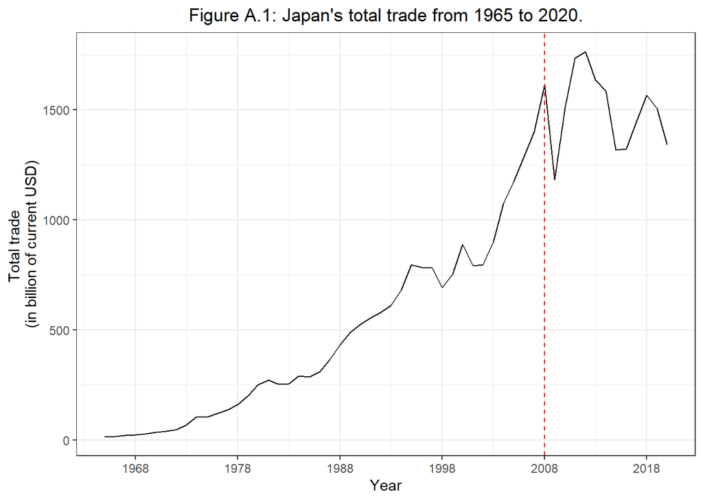

```r
# We create a new dataset 'trade_japan' with three columns: 1. Total amount of trade (imports and exports) 'total_trade' by year; 2. Total amount of imports 'total_imports' per year; 3. Total amount of exports 'total_exports' by year. We remove 2021 since there are no trade flows for this year.

# We first plot the total amount of trade flows considering imports and exports.

trade_japan <- subset(asean_selected_rta, iso3_d=="JPN" | iso3_o=="JPN") %>%
  filter(year != 2021) %>%
  group_by(year) %>%
  summarise(total_trade = sum(tradeflow_comtrade_d),
            total_imports = sum(tradeflow_comtrade_d[iso3_d == "JPN"]),
            total_exports = sum(tradeflow_comtrade_d[iso3_o == "JPN"]))

fig_a1 <- ggplot(trade_japan, aes(x = year, y = total_trade/1000000)) +
  geom_line() +
  geom_vline(xintercept = 2008, linetype = "dashed", color = "red") +
  labs(title = "Figure A.1: Japan's total trade from 1965 to 2020.", x = "Year", y = "Total trade \n(in billion of current USD)") +
  theme_bw() +
  theme(plot.title = element_text(hjust = 0.5)) +
  scale_x_continuous(breaks = seq(1968, 2018, 10), limits = c(1965, 2020))

fig_a1
```

```r
# Exporting the figure to png

png("./fig_a1.png", width=600, height=400)
print(fig_a1)
dev.off()
```

### 1.2. Imports and exports

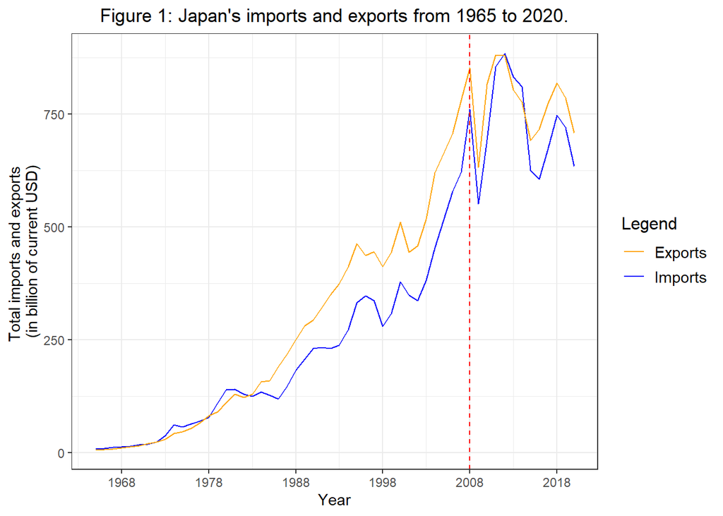

```r
# We now plot a graph with both total imports and total exports of Japan to see their evolution between 1965 and 2008.

fig_1 <- ggplot() +
  geom_line(data=trade_japan, aes(x = year, y = total_imports/1000000, color="Imports")) +
  geom_line(data=trade_japan, aes(x = year, y = total_exports/1000000, color="Exports")) +
  geom_vline(xintercept = 2008, linetype = "dashed", color = "red") +
  labs(title = "Figure 1: Japan's imports and exports from 1965 to 2020.", x = "Year", y = "Total imports and exports \n(in billion of current USD)") +
  theme_bw() +
  theme(plot.title = element_text(hjust = 0.5), legend.title = element_text(size = 12), legend.text=element_text(size=11)) +
  scale_x_continuous(breaks = seq(1968, 2018, 10), limits = c(1965, 2020)) +
  scale_color_manual(name = "Legend", values = c("Imports" = "blue", "Exports" = "orange"))

fig_1
```

```r
# Exporting the figure to png

png("./fig_1.png", width=500, height=300)
print(fig_1)
dev.off()
```

## 2. AJCEP’s member states trade level

Here, we create three dataset: 1. Global trade level of each AJCEP member state (imports and exports) ‘total_trade_acjep’ per year; 2. Total imports of each AJCEP member state ‘total_imports_ajcep’ per year; 3. Total exports of each AJCEP member state ‘total_exports_ajcep’ per year.

### 2.1. Global trade level

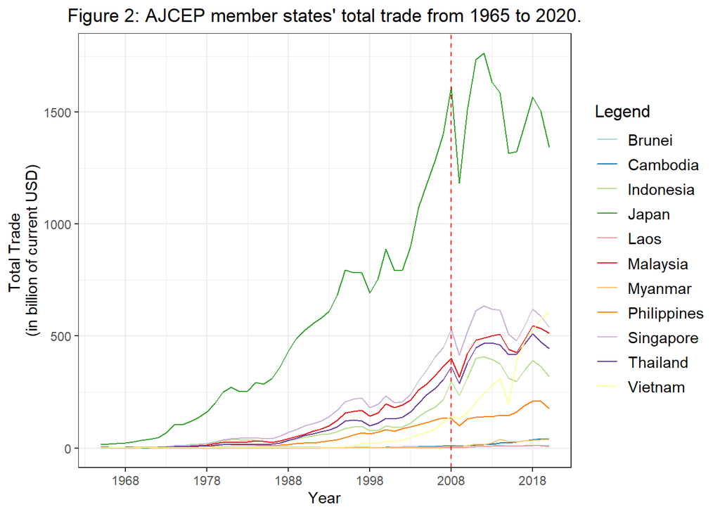

```r
# We create a new dataset 'total_trade_acjep' with reported in it the total amount of trade by country and by year for all members of AJCEP agreement.

total_trade_ajcep <- subset(asean_selected_rta, iso3_d %in% c("BRN", "KHM", "IDN", "LAO", "MYS", "MMR", "PHL", "SGP", "THA", "VNM", "JPN") | iso3_o %in% c("BRN", "KHM", "IDN", "LAO", "MYS", "MMR", "PHL", "SGP", "THA", "VNM", "JPN")) %>%
  filter(year != 2021) %>%
  group_by(year) %>%
  summarise(total_trade = sum(tradeflow_comtrade_d),
            total_trade_JPN = sum(tradeflow_comtrade_d[iso3_d == "JPN" | iso3_o == "JPN"]),
            total_trade_BRN = sum(tradeflow_comtrade_d[iso3_d == "BRN" | iso3_o == "BRN"]),
            total_trade_KHM = sum(tradeflow_comtrade_d[iso3_d == "KHM" | iso3_o == "KHM"]),
            total_trade_IDN = sum(tradeflow_comtrade_d[iso3_d == "IDN" | iso3_o == "IDN"]),
            total_trade_LAO = sum(tradeflow_comtrade_d[iso3_d == "LAO" | iso3_o == "LAO"]),
            total_trade_MYS = sum(tradeflow_comtrade_d[iso3_d == "MYS" | iso3_o == "MYS"]),
            total_trade_MMR = sum(tradeflow_comtrade_d[iso3_d == "MMR" | iso3_o == "MMR"]),
            total_trade_PHL = sum(tradeflow_comtrade_d[iso3_d == "PHL" | iso3_o == "PHL"]),
            total_trade_SGP = sum(tradeflow_comtrade_d[iso3_d == "SGP" | iso3_o == "SGP"]),
            total_trade_THA = sum(tradeflow_comtrade_d[iso3_d == "THA" | iso3_o == "THA"]),
            total_trade_VNM = sum(tradeflow_comtrade_d[iso3_d == "VNM" | iso3_o == "VNM"]))


# We plot the evolution of the total amount of trade for each country of AJCEP from 1965 to 2020.

fig_2 <- ggplot(total_trade_ajcep, aes(x = year)) +
  geom_line(aes(y = total_trade_JPN/1000000, color = "Japan")) +
  geom_line(aes(y = total_trade_IDN/1000000, color = "Indonesia")) +
  geom_line(aes(y = total_trade_MYS/1000000, color = "Malaysia")) +
  geom_line(aes(y = total_trade_BRN/1000000, color = "Brunei")) +
  geom_line(aes(y = total_trade_KHM/1000000, color = "Cambodia")) +
  geom_line(aes(y = total_trade_LAO/1000000, color = "Laos")) +
  geom_line(aes(y = total_trade_MMR/1000000, color = "Myanmar")) +
  geom_line(aes(y = total_trade_PHL/1000000, color = "Philippines")) +
  geom_line(aes(y = total_trade_SGP/1000000, color = "Singapore")) +
  geom_line(aes(y = total_trade_THA/1000000, color = "Thailand")) +
  geom_line(aes(y = total_trade_VNM/1000000, color = "Vietnam")) +
  scale_color_brewer(name="Legend", palette = "Paired") +
  labs(x = "Year", y = "Total Trade \n(in billion of current USD)", title = "Figure 2: AJCEP member states' total trade from 1965 to 2020.") +
  theme_bw() +
  geom_vline(xintercept = 2008, linetype = "dashed", color = "red") +
  theme(plot.title = element_text(hjust = 0.5), legend.title = element_text(size = 12), legend.text=element_text(size=11)) +
  scale_x_continuous(breaks = seq(1968, 2018, 10), limits = c(1965, 2020))

fig_2
```

```r
# Exporting the figure to png

png("./fig_2.png", width=500, height=300)
print(fig_2)
dev.off()
```

### 2.2. Imports

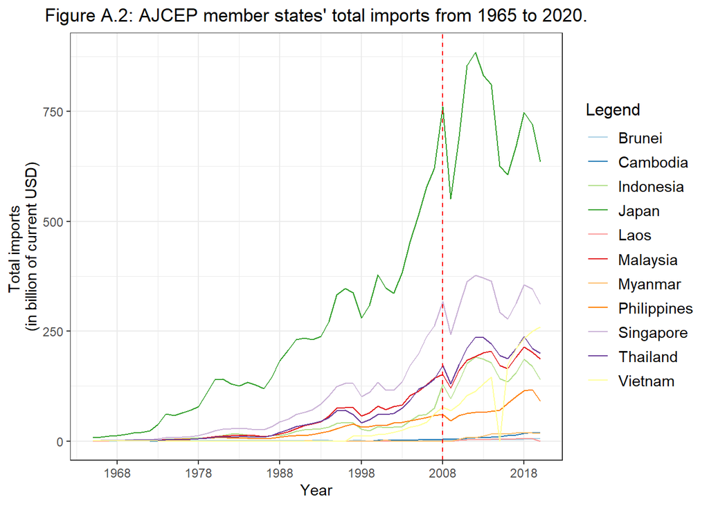

```r
# We now create a dataset 'total_imports_ajcep' where we have the total amount of imports for each country by year.

total_imports_ajcep <- subset(asean_selected_rta, iso3_d %in% c("BRN", "KHM", "IDN", "LAO", "MYS", "MMR", "PHL", "SGP", "THA", "VNM", "JPN") | iso3_o %in% c("BRN", "KHM", "IDN", "LAO", "MYS", "MMR", "PHL", "SGP", "THA", "VNM", "JPN")) %>%
  filter(year != 2021) %>%
  group_by(year) %>%
  summarise(total_imports = sum(tradeflow_comtrade_d[iso3_d %in% c("JPN", "BRN", "KHM", "IDN", "LAO", "MYS", "MMR", "PHL", "SGP", "THA", "VNM")]),
            total_imports_JPN = sum(tradeflow_comtrade_d[iso3_d == "JPN"]),
            total_imports_BRN = sum(tradeflow_comtrade_d[iso3_d == "BRN"]),
            total_imports_KHM = sum(tradeflow_comtrade_d[iso3_d == "KHM"]),
            total_imports_IDN = sum(tradeflow_comtrade_d[iso3_d == "IDN"]),
            total_imports_LAO = sum(tradeflow_comtrade_d[iso3_d == "LAO"]),
            total_imports_MYS = sum(tradeflow_comtrade_d[iso3_d == "MYS"]),
            total_imports_MMR = sum(tradeflow_comtrade_d[iso3_d == "MMR"]),
            total_imports_PHL = sum(tradeflow_comtrade_d[iso3_d == "PHL"]),
            total_imports_SGP = sum(tradeflow_comtrade_d[iso3_d == "SGP"]),
            total_imports_THA = sum(tradeflow_comtrade_d[iso3_d == "THA"]),
            total_imports_VNM = sum(tradeflow_comtrade_d[iso3_d == "VNM"]))

# We plot the total level of imports for each AJCEP country and for each year.

fig_a2 <- ggplot(total_imports_ajcep, aes(x = year)) +
  geom_line(aes(y = total_imports_JPN/1000000, color = "Japan")) +
  geom_line(aes(y = total_imports_IDN/1000000, color = "Indonesia")) +
  geom_line(aes(y = total_imports_MYS/1000000, color = "Malaysia")) +
  geom_line(aes(y = total_imports_BRN/1000000, color = "Brunei")) +
  geom_line(aes(y = total_imports_KHM/1000000, color = "Cambodia")) +
  geom_line(aes(y = total_imports_LAO/1000000, color = "Laos")) +
  geom_line(aes(y = total_imports_MMR/1000000, color = "Myanmar")) +
  geom_line(aes(y = total_imports_PHL/1000000, color = "Philippines")) +
  geom_line(aes(y = total_imports_SGP/1000000, color = "Singapore")) +
  geom_line(aes(y = total_imports_THA/1000000, color = "Thailand")) +
  geom_line(aes(y = total_imports_VNM/1000000, color = "Vietnam")) +
  scale_color_brewer(name="Legend", palette = "Paired") +
  labs(x = "Year", y = "Total imports \n(in billion of current USD)", title = "Figure A.2: AJCEP member states' total imports from 1965 to 2020.") +
  theme_bw() +
  geom_vline(xintercept = 2008, linetype = "dashed", color = "red") +
  theme(plot.title = element_text(hjust = 0.5), legend.title = element_text(size = 12), legend.text=element_text(size=11)) +
  scale_x_continuous(breaks = seq(1968, 2018, 10), limits = c(1965, 2020))

fig_a2
```

```r
# Exporting the figure to png

png("./fig_a2.png", width=600, height=400)
print(fig_a2)
dev.off()
```

### 2.3. Exports

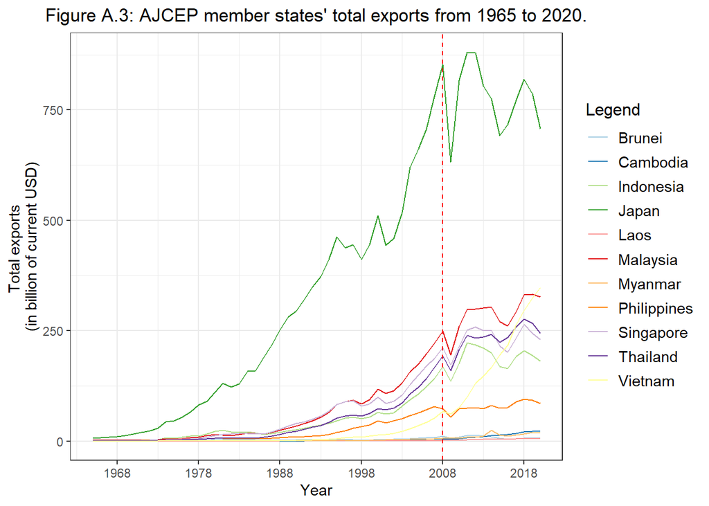

```r
# We now create a dataset 'total_imports_ajcep' where we have the total amount of imports for each country by year.

total_exports_ajcep <- subset(asean_selected_rta, iso3_d %in% c("BRN", "KHM", "IDN", "LAO", "MYS", "MMR", "PHL", "SGP", "THA", "VNM", "JPN") | iso3_o %in% c("BRN", "KHM", "IDN", "LAO", "MYS", "MMR", "PHL", "SGP", "THA", "VNM", "JPN")) %>%
  filter(year != 2021) %>%
  group_by(year) %>%
  summarise(total_exports = sum(tradeflow_comtrade_d[iso3_o %in% c("JPN", "BRN", "KHM", "IDN", "LAO", "MYS", "MMR", "PHL", "SGP", "THA", "VNM")]),
            total_exports_JPN = sum(tradeflow_comtrade_d[iso3_o == "JPN"]),
            total_exports_BRN = sum(tradeflow_comtrade_d[iso3_o == "BRN"]),
            total_exports_KHM = sum(tradeflow_comtrade_d[iso3_o == "KHM"]),
            total_exports_IDN = sum(tradeflow_comtrade_d[iso3_o == "IDN"]),
            total_exports_LAO = sum(tradeflow_comtrade_d[iso3_o == "LAO"]),
            total_exports_MYS = sum(tradeflow_comtrade_d[iso3_o == "MYS"]),
            total_exports_MMR = sum(tradeflow_comtrade_d[iso3_o == "MMR"]),
            total_exports_PHL = sum(tradeflow_comtrade_d[iso3_o == "PHL"]),
            total_exports_SGP = sum(tradeflow_comtrade_d[iso3_o == "SGP"]),
            total_exports_THA = sum(tradeflow_comtrade_d[iso3_o == "THA"]),
            total_exports_VNM = sum(tradeflow_comtrade_d[iso3_o == "VNM"]))

# We plot the total level of imports for each AJCEP country and for each year.

fig_a3 <- ggplot(total_exports_ajcep, aes(x = year)) +
  geom_line(aes(y = total_exports_JPN/1000000, color = "Japan")) +
  geom_line(aes(y = total_exports_IDN/1000000, color = "Indonesia")) +
  geom_line(aes(y = total_exports_MYS/1000000, color = "Malaysia")) +
  geom_line(aes(y = total_exports_BRN/1000000, color = "Brunei")) +
  geom_line(aes(y = total_exports_KHM/1000000, color = "Cambodia")) +
  geom_line(aes(y = total_exports_LAO/1000000, color = "Laos")) +
  geom_line(aes(y = total_exports_MMR/1000000, color = "Myanmar")) +
  geom_line(aes(y = total_exports_PHL/1000000, color = "Philippines")) +
  geom_line(aes(y = total_exports_SGP/1000000, color = "Singapore")) +
  geom_line(aes(y = total_exports_THA/1000000, color = "Thailand")) +
  geom_line(aes(y = total_exports_VNM/1000000, color = "Vietnam")) +
  scale_color_brewer(name="Legend", palette = "Paired") +
  labs(x = "Year", y = "Total exports \n(in billion of current USD)", title = "Figure A.3: AJCEP member states' total exports from 1965 to 2020.") +
  theme_bw() +
  geom_vline(xintercept = 2008, linetype = "dashed", color = "red") +
  theme(plot.title = element_text(hjust = 0.5), legend.title = element_text(size = 12), legend.text=element_text(size=11)) +
  scale_x_continuous(breaks = seq(1968, 2018, 10), limits = c(1965, 2020))

fig_a3
```

```r
# Exporting the figure to png

png("./fig_a3.png", width=600, height=400)
print(fig_a3)
dev.off()
```

## 3. Japan-ASEAN trade

We want to focus on the trade between Japan and ASEAN only and not on the trade with the RoW anymore. (1) Japan’s exports to ASEAN (= ASEAN’s imports from Japan) (2) Japan’s imports from ASEAN (= ASEAN’s exports to Japan)

```r
# We create a new dataset 'trade_japan_asean' where we can see the trade within AJCEP countries.

trade_japan_asean <- asean_selected_rta %>%
  select(year, pair, iso3_o, iso3_d, tradeflow_comtrade_d) %>%
  filter(iso3_d %in% c("BRN", "KHM", "IDN", "LAO", "MYS", "MMR", "PHL", "SGP", "THA", "VNM","JPN") & iso3_o %in% c("BRN", "KHM", "IDN", "LAO", "MYS", "MMR", "PHL", "SGP", "THA", "VNM","JPN")) %>%
  filter(year != 2021)
```

### 3.1. Japan’s total exports to each ASEAN country

```r
# We firstly focus on Japan's total exports to each ASEAN country in 2000 and 2012.

japan_exports <- trade_japan_asean %>%
  filter(iso3_o == "JPN") %>%
  filter(year %in% c(2000, 2012) & iso3_d != "JPN") %>%
  group_by(iso3_d) %>%
  summarize(`2000` = sum(tradeflow_comtrade_d[year == 2000]),
            `2012` = sum(tradeflow_comtrade_d[year == 2012]),
            `Evolution (in %)` = round(((`2012` - `2000`) / `2000`) * 100, 2)) %>%
  pivot_longer(cols = -iso3_d, names_to = "year", values_to = "value") %>%
  pivot_wider(names_from = "iso3_d", values_from = "value")

names(japan_exports) <- c("Year", "Brunei", "Indonesia", "Cambodia", "Laos", "Myanmar", "Malaysia", "Philippines", "Singapore", "Thailand", "Vietnam")

japan_exports
```

| Year | Brunei | Indonesia | Cambodia | Laos | Myanmar | Malaysia | Philippines | Singapore | Thailand | Vietnam |
| --- | --- | --- | --- | --- | --- | --- | --- | --- | --- | --- |
| 2000 | 0 | 5.4e+06 | 5.93e+04 | 0 | 0 | 1.71e+07 | 6.96e+06 | 2.3e+07 | 1.53e+07 | 2.3e+06 |
| 2012 | 2.68e+05 | 2.28e+07 | 2.4e+05 | 7.2e+04 | 8.86e+05 | 2.02e+07 | 6.88e+06 | 2.29e+07 | 4.85e+07 | 1.16e+07 |
| Evolution (in %) | Inf | 322 | 304 | Inf | Inf | 17.7 | -1.2 | -0.07 | 217 | 404 |

### 3.2. Japan’s total imports from each ASEAN country

```r
# We can now focus on Japan's total imports from each ASEAN country in 2000 and 2012.

japan_imports <- trade_japan_asean %>%
  filter(iso3_d == "JPN") %>%
  filter(year %in% c(2000, 2012) & iso3_o != "JPN") %>%
  group_by(iso3_o) %>%
  summarize(`2000` = sum(tradeflow_comtrade_d[year == 2000]),
            `2012` = sum(tradeflow_comtrade_d[year == 2012]),
            `Evolution (in %)` = round(((`2012` - `2000`) / `2000`) * 100, 2)) %>%
  pivot_longer(cols = -iso3_o, names_to = "year", values_to = "value") %>%
  pivot_wider(names_from = "iso3_o", values_from = "value")

names(japan_imports) <- c("Year", "Brunei", "Indonesia", "Cambodia", "Laos", "Myanmar", "Malaysia", "Philippines", "Singapore", "Thailand", "Vietnam")

japan_imports
```

| Year | Brunei | Indonesia | Cambodia | Laos | Myanmar | Malaysia | Philippines | Singapore | Thailand | Vietnam |
| --- | --- | --- | --- | --- | --- | --- | --- | --- | --- | --- |
| 2000 | 1.65e+06 | 1.64e+07 | 5.22e+04 | 1.2e+04 | 1.19e+05 | 1.45e+07 | 7.2e+06 | 6.38e+06 | 1.06e+07 | 2.64e+06 |
| 2012 | 5.99e+06 | 3.23e+07 | 4.04e+05 | 1.24e+05 | 6.72e+05 | 3.28e+07 | 9.32e+06 | 8.68e+06 | 2.36e+07 | 1.51e+07 |
| Evolution (in %) | 262 | 97.1 | 675 | 933 | 463 | 127 | 29.4 | 36.1 | 123 | 471 |

### 3.3. Overview

```r
# We create a table with Japan's total levels of imports and exports from and to each ASEAN country both in 2000 and 2012.

table_2_exports <- as_hux(japan_exports) %>%
  set_caption("Table 2: Japan exports to each ASEAN country in 2000 and 2012\n(in thousands of current USD)") %>%
  set_align(everywhere,-1,"center") %>%
  set_top_border(2, everywhere) %>%
  set_right_border(everywhere, 1) %>%
  set_bottom_border(3, everywhere) %>%
  set_number_format(-1, -1, fmt_pretty(digits=1)) %>%
  set_font_size(7.5) %>%
  set_label("table_2_exports")

table_2_exports
```

Table 2: Japan exports to each ASEAN country in 2000 and 2012 (in thousands of current USD)

| Year | Brunei | Indonesia | Cambodia | Laos | Myanmar | Malaysia | Philippines | Singapore | Thailand | Vietnam |
| --- | --- | --- | --- | --- | --- | --- | --- | --- | --- | --- |
| 2000 | 0 | 5,397,199 | 59,301 | 0 | 0 | 17,142,040 | 6,960,292 | 22,962,867 | 15,280,004 | 2,300,947 |
| 2012 | 268,017 | 22,751,222 | 239,798 | 72,045 | 885,653 | 20,173,170 | 6,876,549 | 22,946,184 | 48,509,102 | 11,587,293 |
| Evolution (in %) | Inf | 322 | 304 | Inf | Inf | 18 | -1 | -0.07 | 217 | 404 |

```r
table_1_imports <- as_hux(japan_imports) %>%
  set_caption("Table 1: Japan imports from each ASEAN country in 2000 and 2012\n(in thousands of current USD)") %>%
  set_align(everywhere,-1,"center") %>%
  set_top_border(2, everywhere) %>%
  set_right_border(everywhere, 1) %>%
  set_bottom_border(3, everywhere) %>%
  set_bottom_border_style("double") %>%
  set_number_format(-1, -1, fmt_pretty(digits=1)) %>%
  set_font_size(7.5) %>%
  set_label("table_1_imports")

table_1_imports
```

Table 1: Japan imports from each ASEAN country in 2000 and 2012 (in thousands of current USD)

| Year | Brunei | Indonesia | Cambodia | Laos | Myanmar | Malaysia | Philippines | Singapore | Thailand | Vietnam |
| --- | --- | --- | --- | --- | --- | --- | --- | --- | --- | --- |
| 2000 | 1,653,626 | 16,381,575 | 52,190 | 11,960 | 119,417 | 14,456,714 | 7,199,737 | 6,382,106 | 10,593,435 | 2,639,663 |
| 2012 | 5,990,678 | 32,290,004 | 404,271 | 123,553 | 672,133 | 32,754,331 | 9,315,304 | 8,684,152 | 23,571,249 | 15,079,322 |
| Evolution (in %) | 262 | 97 | 675 | 933 | 463 | 127 | 29 | 36 | 123 | 471 |

```r
width(table_2_exports) = 1.3
width(table_1_imports) = 1.3

# Export the tables to word

table_2_exports_docx = as_flextable(table_2_exports)
save_as_docx(table_2_exports_docx, path = "table_2_exports.docx")

table_1_imports_docx = as_flextable(table_1_imports)
save_as_docx(table_1_imports_docx, path = "table_1_imports.docx")
```

## 4. Japan’s world trade partners

```r
# Dataset with the trade of Japan with all the world.

trade_japan_world <- subset(asean_selected_rta, iso3_d=="JPN" | iso3_o=="JPN") %>%
  filter(year != 2021) %>%
  group_by(year) %>%
  select(year, pair, iso3_d, iso3_o, tradeflow_comtrade_d)
```

### 4.1. Imports of Japan

```r
# We want to work about the imports of Japan from all the world.We also want to add three columns from the dataset 'trade_japan' to add the total trade of Japan, its total exports and its total imports for 2000 and 2012. Therefore, we can add a last column with the share of imports to each country compared to the total imports of Japan.

imports_japan_world <- subset(trade_japan_world, iso3_d=="JPN") %>%
  filter(year %in% c(2000, 2012) & iso3_o != "JPN") %>%
  group_by(year, iso3_o)

imports_japan_world <- imports_japan_world %>%
  left_join(trade_japan, by = "year")

imports_japan_world <- imports_japan_world %>%
  mutate(share_japan_imports = round((tradeflow_comtrade_d/total_imports)*100, 3),
         share_japan_imports = paste(share_japan_imports, "%", sep = ""))

imports_japan_world$share_japan_imports <- as.numeric(gsub("%", "", imports_japan_world$share_japan_imports))
```

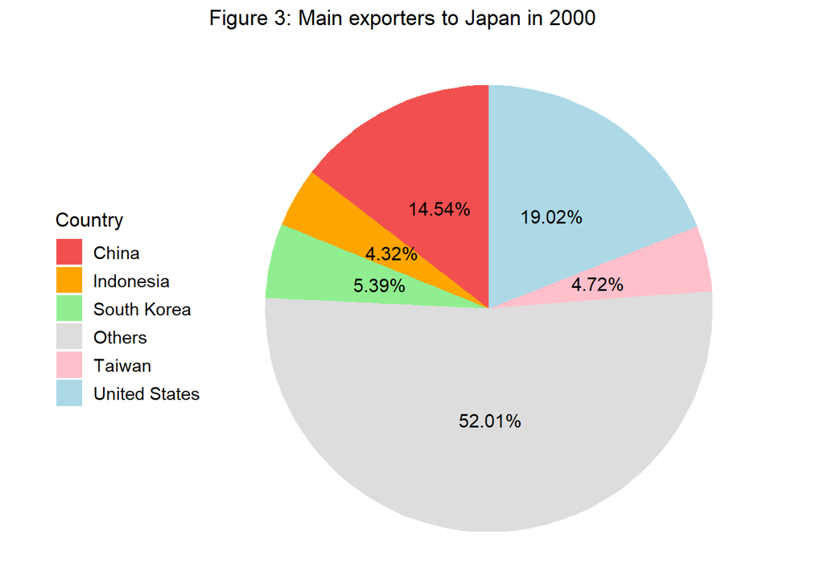

```r
# We calculate the top 5 imports origins of Japan in 2000.

top_imports_2000_sum <- imports_japan_world %>%
  filter(year == 2000) %>%
  group_by(iso3_o) %>%
  summarize(total_imports = sum(tradeflow_comtrade_d),
            share_japan_imports = sum(share_japan_imports)) %>%
  top_n(5, share_japan_imports) %>%
  arrange(desc(share_japan_imports)) %>%
  add_row(iso3_o = "Others", total_imports = 0,
          share_japan_imports = 52.01)

# We plot a graph (pie chart) for 2000.

colors3 <- c("#F25050","orange","lightgreen","#DDDDDD","pink","lightblue")

fig_3 <- ggplot(top_imports_2000_sum, aes(x = "", y = share_japan_imports, fill = iso3_o)) +
  geom_bar(width = 1, stat = "identity") +
  coord_polar(theta = "y") +
  labs(title = "Figure 3: Main exporters to Japan in 2000", fill = "Country", x = NULL, y = NULL) +
  theme_void() +
  theme(legend.position = "left", legend.title = element_text(size = 12), legend.text=element_text(size=11)) +
  geom_text(aes(label = paste0(round(share_japan_imports, 2), "%")),
            position = position_stack(vjust = 0.5), size = 4) +
  scale_fill_manual(name = "Country", values = colors3,
                    labels = c("China", "Indonesia", "South Korea", "Others", "Taiwan", "United States"))

fig_3
```

```r
# Exporting the figure to png

png("./fig_3.png", width=400, height=400)
print(fig_3)
dev.off()
```

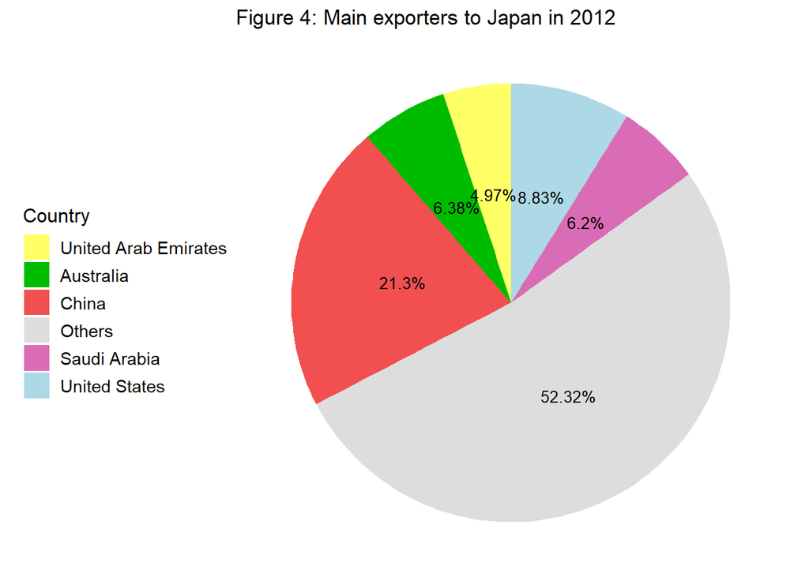

```r
# We calculate the top 5 imports origins of Japan in 2012.

top_imports_2012_sum <- imports_japan_world %>%
  filter(year == 2012) %>%
  group_by(iso3_o) %>%
  summarize(total_imports = sum(tradeflow_comtrade_d),
            share_japan_imports = sum(share_japan_imports)) %>%
  top_n(5, share_japan_imports) %>%
  arrange(desc(share_japan_imports)) %>%
  add_row(iso3_o = "Others", total_imports = 0,
          share_japan_imports = 52.32)

# We plot a graph (pie chart) for 2012.

colors4 <- c("#FFFF66","#00BC00","#F25050","#DDDDDD","#DA6CB5","lightblue")

fig_4 <- ggplot(top_imports_2012_sum, aes(x = "", y = share_japan_imports, fill = iso3_o)) +
  geom_bar(width = 1, stat = "identity") +
  coord_polar(theta = "y") +
  labs(title = "Figure 4: Main exporters to Japan in 2012", fill = "Country", x = NULL, y = NULL) +
  theme_void() +
  theme(legend.position = "left", legend.title = element_text(size = 12), legend.text=element_text(size=11)) +
  geom_text(aes(label = paste0(round(share_japan_imports, 2), "%")),
            position = position_stack(vjust = 0.5), size = 3.5) +
  scale_fill_manual(name = "Country", values = colors4,
                    labels = c("United Arab Emirates", "Australia", "China", "Others", "Saudi Arabia", "United States"))

fig_4
```

```r
# Exporting the figure to png

png("./fig_4.png", width=400, height=400)
print(fig_4)
dev.off()
```

### 4.2. Exports of Japan

```r
# Exports of Japan in all the world.

exports_japan_world <- subset(trade_japan_world, iso3_o=="JPN") %>%
  filter(year %in% c(2000, 2012) & iso3_d != "JPN") %>%
  group_by(year, iso3_d)

exports_japan_world <- exports_japan_world %>%
  left_join(trade_japan, by = "year")

exports_japan_world <- exports_japan_world %>%
  mutate(share_japan_exports = round((tradeflow_comtrade_d/total_exports)*100, 3),
         share_japan_exports = paste(share_japan_exports, "%", sep = ""))

exports_japan_world$share_japan_exports <- as.numeric(gsub("%", "", exports_japan_world$share_japan_exports))
```

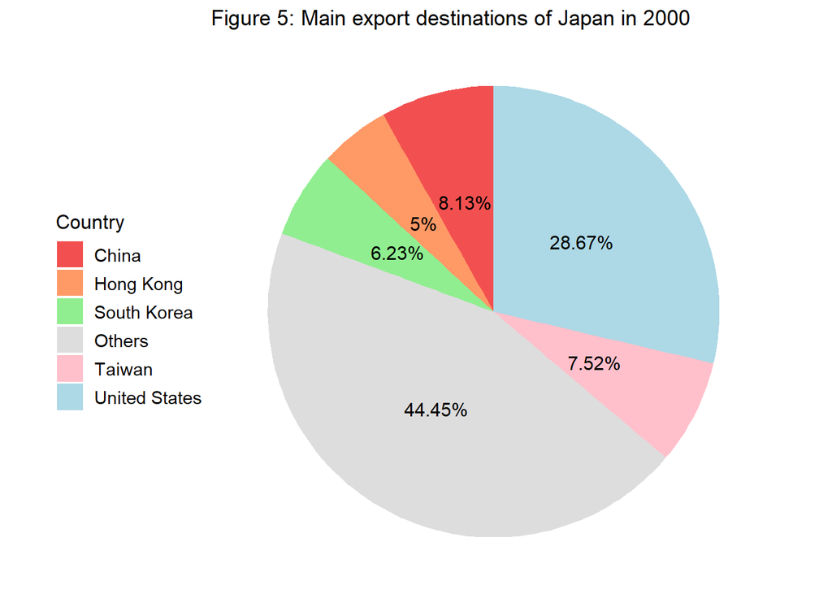

```r
# We calculate the top 5 export destinations of Japan in 2000.

top_exports_2000_sum <- exports_japan_world %>%
  filter(year == 2000) %>%
  group_by(iso3_d) %>%
  summarize(total_exports = sum(tradeflow_comtrade_d),
            share_japan_exports = sum(share_japan_exports)) %>%
  top_n(5, share_japan_exports) %>%
  arrange(desc(share_japan_exports)) %>%
  add_row(iso3_d = "Others", total_exports = 0,
          share_japan_exports = 44.45)

# We plot a graph (pie chart) for 2000.

colors5 <- c("#F25050", "#FF9966","lightgreen","#DDDDDD","pink","lightblue")

fig_5 <- ggplot(top_exports_2000_sum, aes(x = "", y = share_japan_exports, fill = iso3_d)) +
  geom_bar(width = 1, stat = "identity") +
  coord_polar(theta = "y") +
  labs(title = "Figure 5: Main export destinations of Japan in 2000", fill = "Country", x = NULL, y = NULL) +
  theme_void() +
  theme(legend.position = "left", legend.title = element_text(size = 12), legend.text=element_text(size=11)) +
  geom_text(aes(label = paste0(round(share_japan_exports, 2), "%")),
            position = position_stack(vjust = 0.5), size = 4) +
  scale_fill_manual(name = "Country", values = colors5,
                    labels = c("China", "Hong Kong", "South Korea", "Others", "Taiwan", "United States"))

fig_5
```

```r
# Exporting the figure to png

png("./fig_5.png", width=400, height=400)
print(fig_5)
dev.off()
```

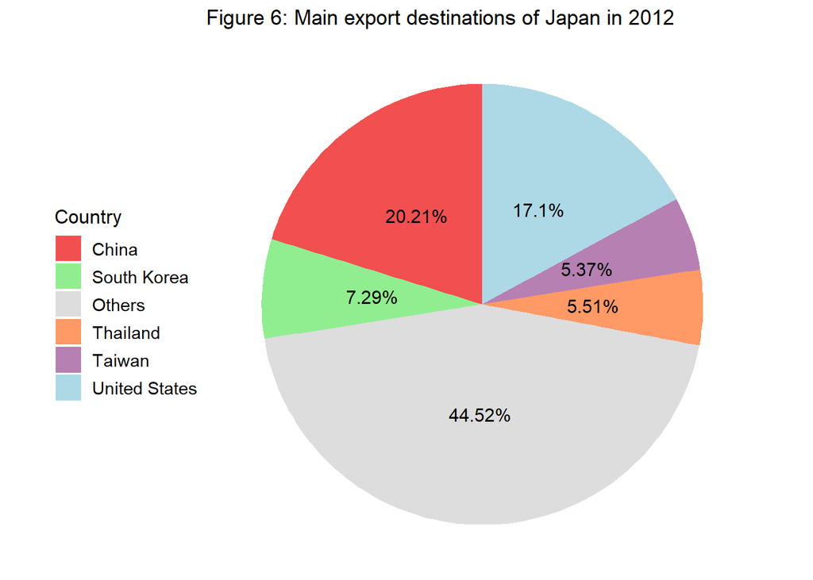

```r
# We calculate the top 5 export destinations of Japan in 2012.

top_exports_2012_sum <- exports_japan_world %>%
  filter(year == 2012) %>%
  group_by(iso3_d) %>%
  summarize(total_exports = sum(tradeflow_comtrade_d),
            share_japan_exports = sum(share_japan_exports)) %>%
  top_n(5, share_japan_exports) %>%
  arrange(desc(share_japan_exports)) %>%
  add_row(iso3_d = "Others", total_exports = 0,
          share_japan_exports = 44.52)

# We plot a graph (pie chart) for 2012.

colors6 <- c("#F25050", "lightgreen","#DDDDDD","#FF9966","#B680B2","lightblue")

fig_6 <- ggplot(top_exports_2012_sum, aes(x = "", y = share_japan_exports, fill = iso3_d)) +
  geom_bar(width = 1, stat = "identity") +
  coord_polar(theta = "y") +
  labs(title = "Figure 6: Main export destinations of Japan in 2012", fill = "Country", x = NULL, y = NULL) +
  theme_void() +
  theme(legend.position = "left", legend.title = element_text(size = 12), legend.text=element_text(size=11)) +
  geom_text(aes(label = paste0(round(share_japan_exports, 2), "%")),
            position = position_stack(vjust = 0.5), size = 4) +
  scale_fill_manual(name = "Country", values = colors6,
                    labels = c("China", "South Korea", "Others", "Thailand", "Taiwan", "United States"))

fig_6
```

```r
# Exporting the figure to png

png("./fig_6.png", width=400, height=400)
print(fig_6)
dev.off()
```